# **TP R Introduction à la statistique**

### 1.2.3 **Représentations graphiques**

**La fonction** `plot` est la fonction générique de graphe

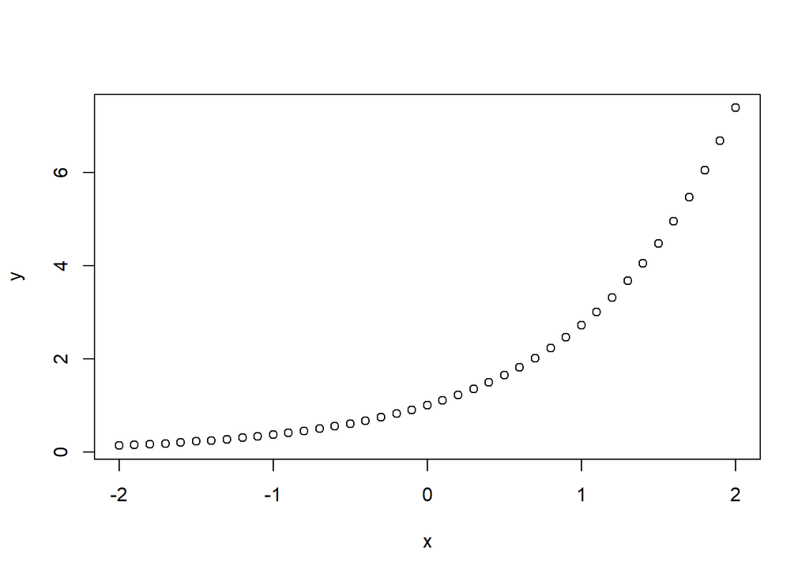

```r
x=seq(-2,2,by=0.1)
y=exp(x)
plot(x,y)
```

Il est possible de parametrer l’affichage obtenu(couleurs,etc). Voici un bref apreçu des options de la fonction plot, vous pouvez regarder l’aide( en tapant `?plot`) pour plus de details. Nous aurons de toutes les façon l’occasion de revenir sur l’utilisation de cette fonction.

- **type** (chaine de charactères) “p” pour points, “l” pour lignes, “b” pour les deux (both);
- **main** (chaine de charactères) un titre pour le graphique;
- **sub** (chaine de charactères) un sous-titre pour le graphique;
- **xlab** (chaine de charactères) un titre pour l’axe des abscisses;
- **ylab** (chaine de charactères) un titre pour l’axe des ordonnées;
- **col** (vecteur de chaines de charactères) la ou les couleurs(s) à utiliser;
- **etc…**

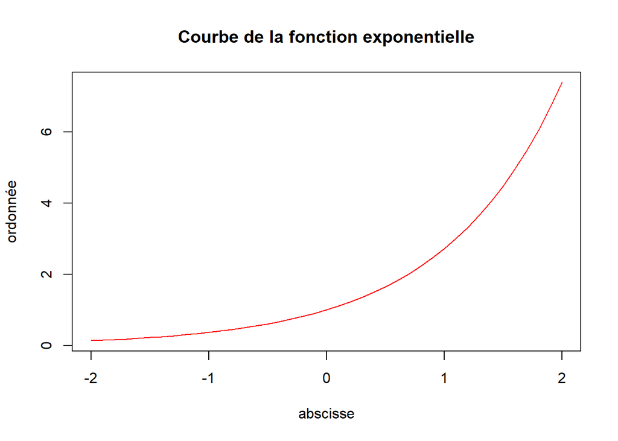

```r
plot(x,y,pch = 1, type="l", col="red", main = "Courbe de la fonction exponentielle", xlab="abscisse"
, ylab= "ordonnée" )
```

## 1.3 **Criminalité - Peine de mort**

Le but de l’étude statistique de cette partie est de s’éclairer sur le lien potentiel entre abolition de la peine de mort et taux de criminalité. Nous resterons néanmoins très prudent sur les conclusions que l’on peut rendre avec des outils de statistiques descriptives. Nous vous conseillons dès à présent d’allumer votre ordinateur et de lancer le logiciel R.

J’ai malheureusement renversé mon café sur la colonne *taux de criminalité*.

### 1.3.1 **Construction de la variable taux de criminalité pour les états ayant aboli la peine de mort**

```r
 murder=c(7,34,72,9,21,26,144,31,22,319,76,625,144)
 population=c(622,3008,5266,647,1395,1318,5655,1053,698,8708,1820,9970,2010)
```

*On rappelle que dans R, une série statistique est un vecteur horizontal. On peut affecter une valeur à une variable en utilisant au choix <- ou =.*

Calculons la variable abolie09 en divisant terme à terme murder par population et en multipliant par 10 (pour un taux par dizaine de milliers d’habitants).

```r
 abolie09=10*murder/population
```

### 1.3.2 **Comparaison des variables taux de criminalité pour les états ayant aboli ou non la peine de mort**

Nous avons en mémoire la variable abolie09. Je vous propose de mettre en mémoire la variable nonabolie09 qui porte le taux de criminalité dans les pays n’ayant pas aboli la peine de mort en 2009.

```r
 nonabolie09=c(0.075,0.133,0.135,0.142,0.202,0.217,0.223,0.254,0.256,0.287,0.304,
 0.332,0.371,0.394,0.399,0.419,0.435,0.440,0.456,0.463,0.497,0.512,0.512,0.522,
 0.534,0.535,0.552,0.590,0.592,0.610,0.627,0.636,0.675,0.732,0.768,1.082,2.401)
```

Vous noterez l’indispensable d’utiliser d’autres méthodes d’acquisition des données pour les grandes séries. Nous pouvons vérifier qu’il ne manque pas de valeur en demandant le nombres de valeurs dans la série tapée :

```r
 length(nonabolie09)
```

```
## [1] 37
```

1. A l’aide de la fonction `mean()` calculer les moyennes de **abolie09 et nonabolie09**. Comparer. Que peut-on en conclure ?
2. On rappelle ce qu’est le diagramme *boîte de distribution*.

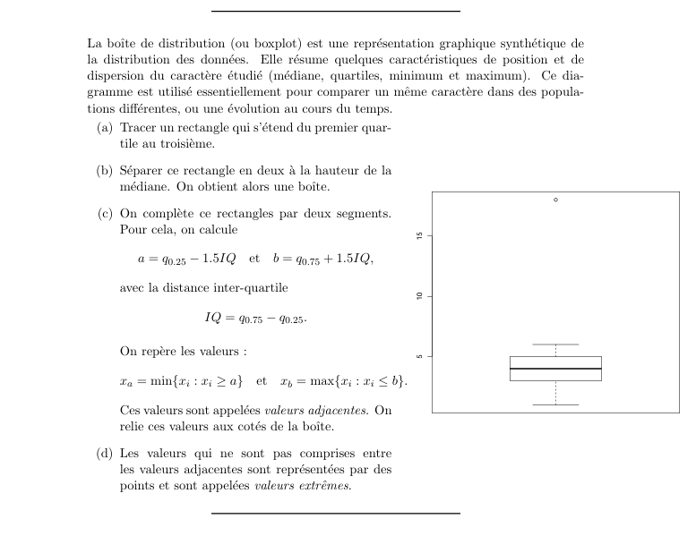

On va tracer les boîtes de distribution des deux séries **abolie09** et **nonabolie09** côte à côte pour avoir une meilleur vision de leur distribution.

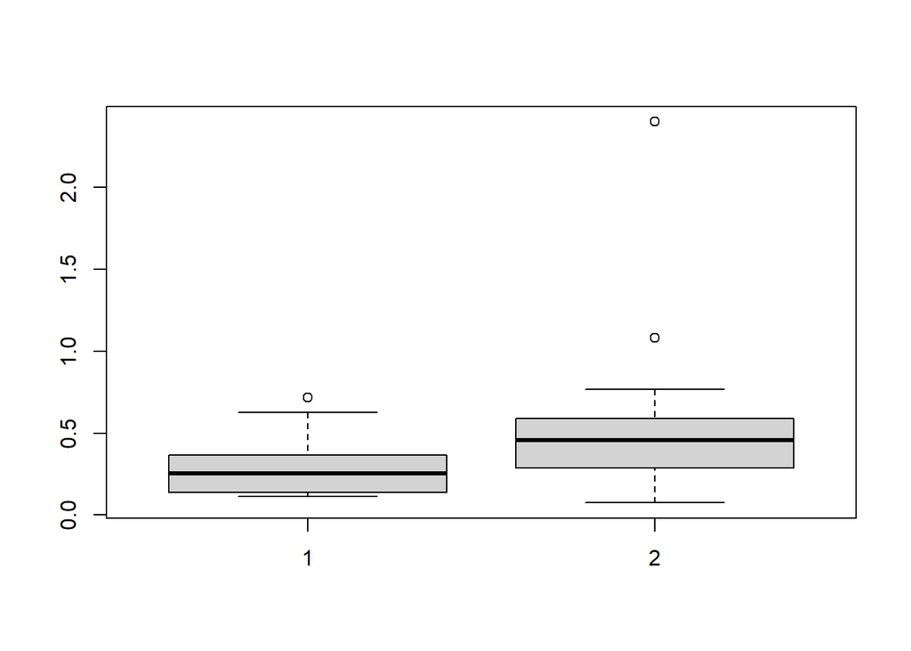

```r
 boxplot(abolie09,nonabolie09)
```

On pourra modifier les paramètres du graphe, par exemple ajouter un titre principal avec le paramètre main :

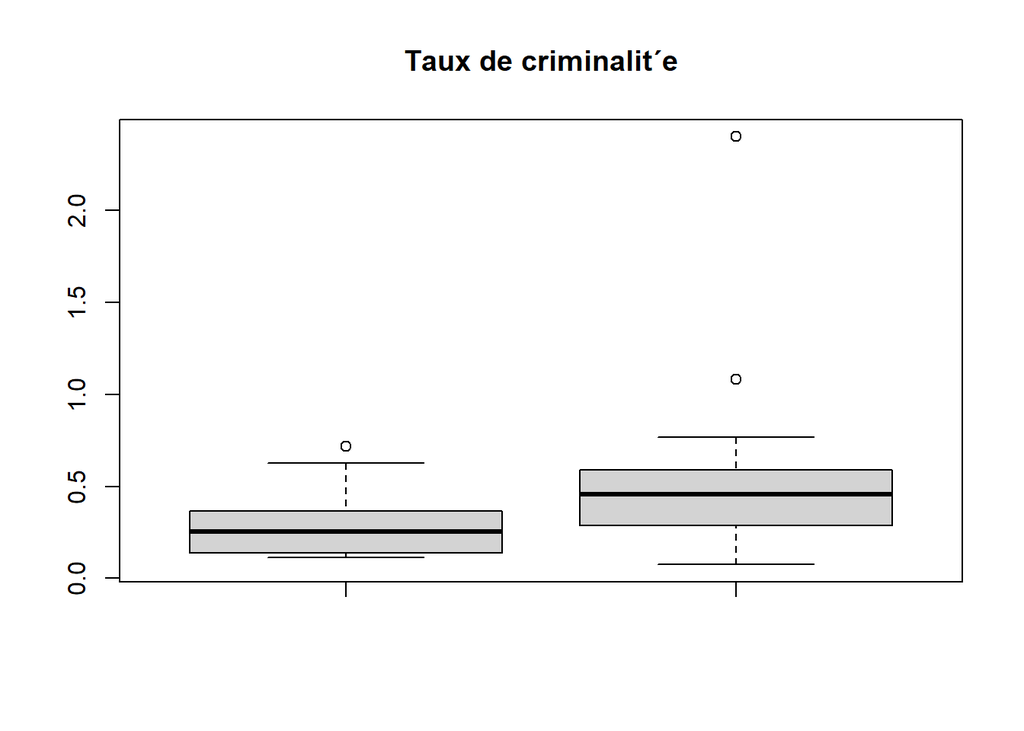

```r
 boxplot(abolie09,nonabolie09,main="Taux de criminalit´e")
```

*Les accents sont pris en charge. Les chaines de caractère doivent être mises entre guillemets*. On peut également changer le nom de chaque variable et sa couleur avec les paramètres **names** et **col** dont les arguments sont des vecteurs portant la caractéristique souhaitée pour chaque série dans l’ordre.

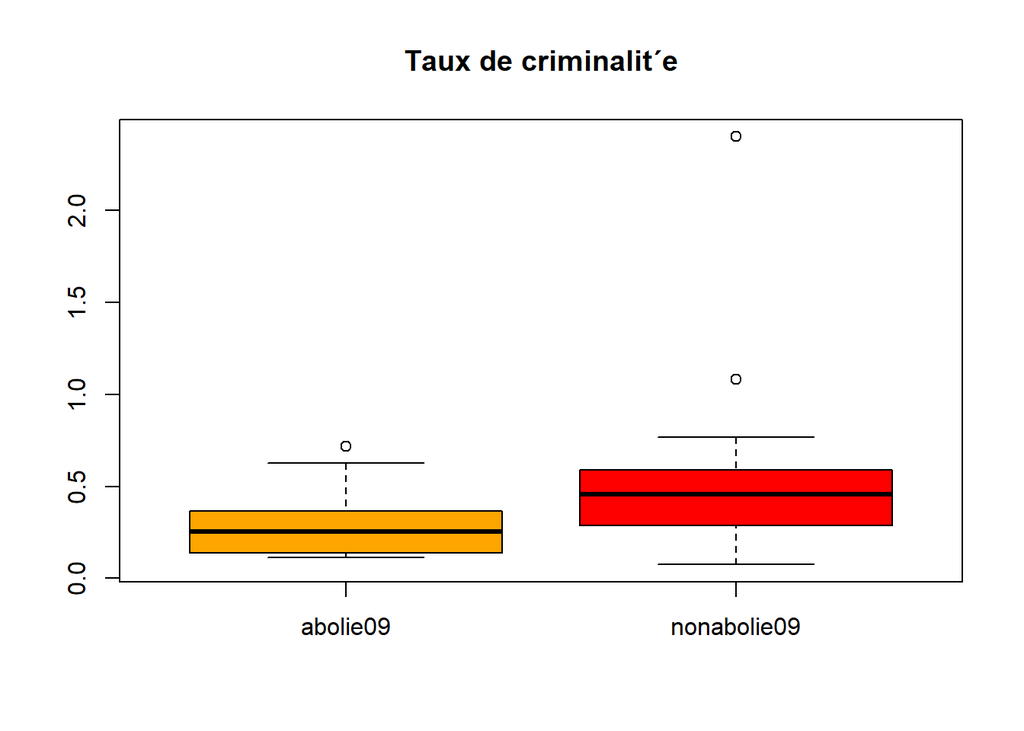

```r
boxplot(abolie09,nonabolie09,main="Taux de criminalit´e",col=c("orange","red"),
 names=c("abolie09","nonabolie09"))
```

Que peut-on déduire de ce graphe ?

3. Peut-on déduire un lien de cause à effet avec ce type détude ?

### 1.3.3 **Autre démarche pour obtenir le boxplot**

Supposons que, comme c’est dans la présentation de l’annexe, les deux séries **abolie09 et nonabolie09** soient concaténées dans un seul vecteur de données

```r
 txmeurtres=c(abolie09,nonabolie09)
```

Faites afficher **txmeurtres** pour vous en persuader. On peut créer la variable qui discrimine l’abolition ou non de la peine de mort.

```r
 pdm=c(rep("oui",13),rep("non",37))
```

Faites afficher pdm pour vérifier que nous avons le statut de l’abolition ou non de la peine de mort pour chaque état dans le même ordre que le taux de criminalité. On pourra obtenir le même boxplot que précdédemment en discriminant les donn´es sur le facteur pdm.

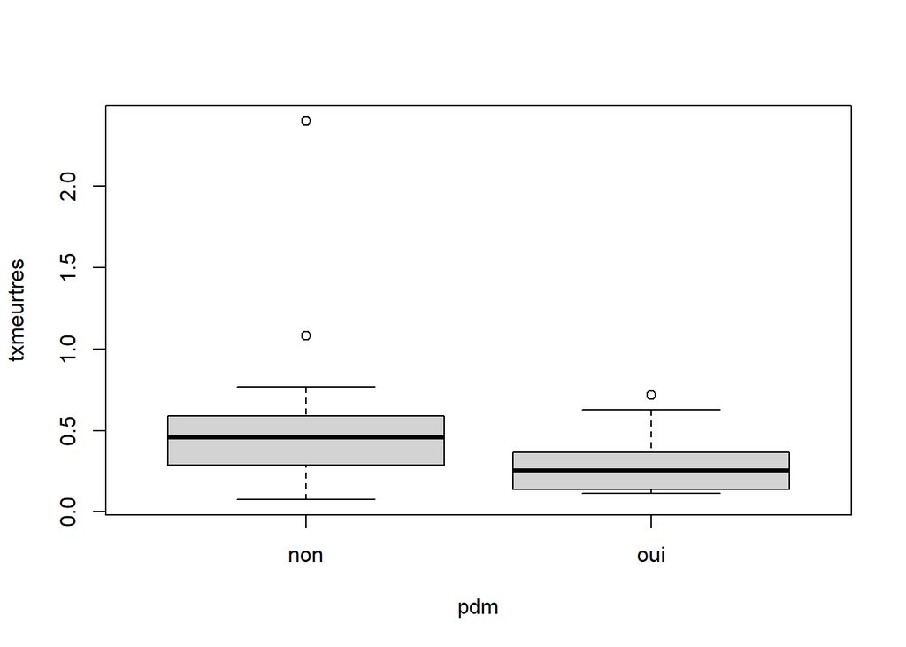

```r
 boxplot(txmeurtres~pdm)
```